# 세미나(4)

SeoHyeong Jeong

2018/01/25

*Source file* ⇒ 세미나_4_.Rmd

## 학습목표

1. Data Verbs: Ranks and Ordering
2. `ggplot2`(3)
3. Regular Expression (i.e. regex)
- reference: UC Berkeley Stat 133 Data Computing By [Adam Lucas](http://rpubs.com/alucas)

## 1. Data Verbs: Ranks and Ordering

data verb `rank()`는 벡터 속의 각각의 숫자를 해당하는 rank로 대체하여 반환한다. 가장 작은 숫자가 rank 1을 가진다.

예시:

```r
c(20:11) %>% rank()
```

```
##  [1] 10  9  8  7  6  5  4  3  2  1
```

`desc() %>% rank()` 의 명령어는 rank가 큰 수부터 1을 갖도록 만든다.

```r
c(20:11) %>% desc() %>% rank()
```

```
##  [1]  1  2  3  4  5  6  7  8  9 10
```

tie가 있는 경우, rank에는 자동적로 평균값이 지정된다.

```r
c(4,4,4,4,4) %>% rank()  #average of 1,2,3,4,5 is 3
```

```
## [1] 3 3 3 3 3
```

```r
c(2,4,2,9,9,8) %>% rank()  # average of 1,2 is 1.5,  average of 5,6 is 5.5
```

```
## [1] 1.5 3.0 1.5 5.5 5.5 4.0
```

dataverb `dplyr::arrange()`는 데이터 프레임을 increasing order로 정렬한다.

```r
mtcars %>%
  arrange(cyl,desc(disp)) %>%  #increasing for cyl, decreasing for disp
  head()
```

| mpg | cyl | disp | hp | drat | wt | qsec | vs | am | gear | carb |
| --- | --- | --- | --- | --- | --- | --- | --- | --- | --- | --- |
| 24.4 | 4 | 146.7 | 62 | 3.69 | 3.190 | 20.00 | 1 | 0 | 4 | 2 |
| 22.8 | 4 | 140.8 | 95 | 3.92 | 3.150 | 22.90 | 1 | 0 | 4 | 2 |
| 21.4 | 4 | 121.0 | 109 | 4.11 | 2.780 | 18.60 | 1 | 1 | 4 | 2 |
| 26.0 | 4 | 120.3 | 91 | 4.43 | 2.140 | 16.70 | 0 | 1 | 5 | 2 |
| 21.5 | 4 | 120.1 | 97 | 3.70 | 2.465 | 20.01 | 1 | 0 | 3 | 1 |
| 22.8 | 4 | 108.0 | 93 | 3.85 | 2.320 | 18.61 | 1 | 1 | 4 | 1 |

예시:

Babynames 데이터 테이블로 예시를 살펴보자.

```r
head(BabyNames)
```

| name | sex | count | year |
| --- | --- | --- | --- |
| Mary | F | 7065 | 1880 |
| Anna | F | 2604 | 1880 |
| Emma | F | 2003 | 1880 |
| Elizabeth | F | 1939 | 1880 |
| Minnie | F | 1746 | 1880 |
| Margaret | F | 1578 | 1880 |

다음은 가장 유명한 BabyNames에 rank를 준다.

```r
BabyNames %>%
  group_by(name) %>%
  summarise(total=sum(count)) %>%
  arrange(desc(total)) %>%
  mutate(rank=rank(total)) %>%
  head()
```

| name | total | rank |
| --- | --- | --- |
| James | 5114325 | 92600 |
| John | 5095590 | 92599 |
| Robert | 4809858 | 92598 |
| Michael | 4315029 | 92597 |
| Mary | 4127615 | 92596 |
| William | 4054318 | 92595 |

```r
BabyNames %>%
  group_by(name) %>%
  summarise(total=sum(count)) %>%
  arrange(desc(total)) %>%
  mutate(rank=rank(desc(total))) %>%
  head()
```

| name | total | rank |
| --- | --- | --- |
| James | 5114325 | 1 |
| John | 5095590 | 2 |
| Robert | 4809858 | 3 |
| Michael | 4315029 | 4 |
| Mary | 4127615 | 5 |
| William | 4054318 | 6 |

50번째로 유명한 이름을 찾으면:

```r
BabyNames %>%
  group_by(name) %>%
  summarise(total=sum(count)) %>%
  mutate(popularity=rank(desc(total))) %>%
  filter( popularity ==50)
```

| name | total | popularity |
| --- | --- | --- |
| Nicholas | 874177 | 50 |

## 2. `ggplot2`(3)

### Geom_denisty plots

`NCHS`에서 다음의 변수들을 선택:

```r
NCHS %>% select(age,weight,sex,diabetic) %>%
  head(3)
```

| age | weight | sex | diabetic |
| --- | --- | --- | --- |
| 2 | 12.5 | female | Not |
| 77 | 75.4 | male | Not |
| 10 | 32.9 | female | Not |

Density glyphs을 사용하면 서로 다른 그룹간의 분포를 비교할 수 있다. 아래는 sex를 그룹으로 설정하여 두 개의 density plot을 그린 것이다.

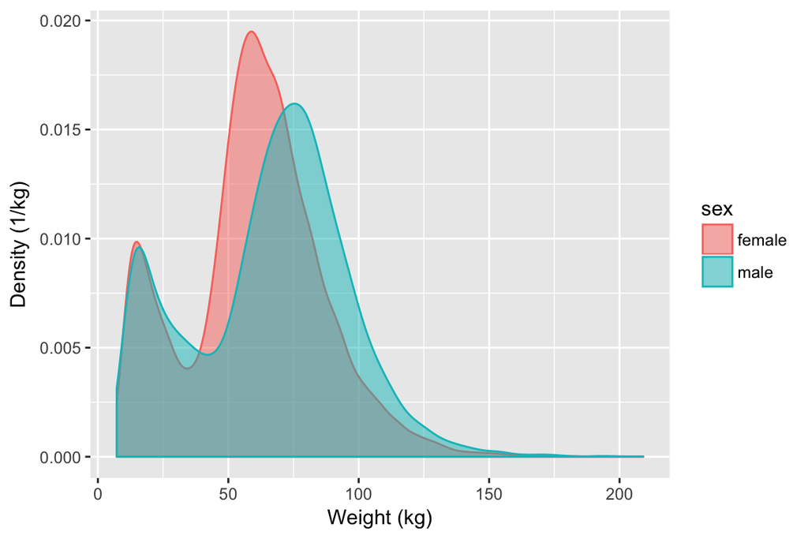

```r
NCHS %>% ggplot( aes(x=weight) ) +
  geom_density(aes(color=sex, fill=sex), alpha=.5) +
  xlab("Weight (kg)") + ylab( "Density (1/kg)")
```

facet을 이용하면 sex 이외의 age 그룹으로 그래프를 표현할 수 있다.

```r
#library(mosaic)  Need library(mosaic) for ntiles()

NCHS <-
  NCHS %>%
  mutate( ageGroup=mosaic::ntiles(age, n=6, format="interval") )
```

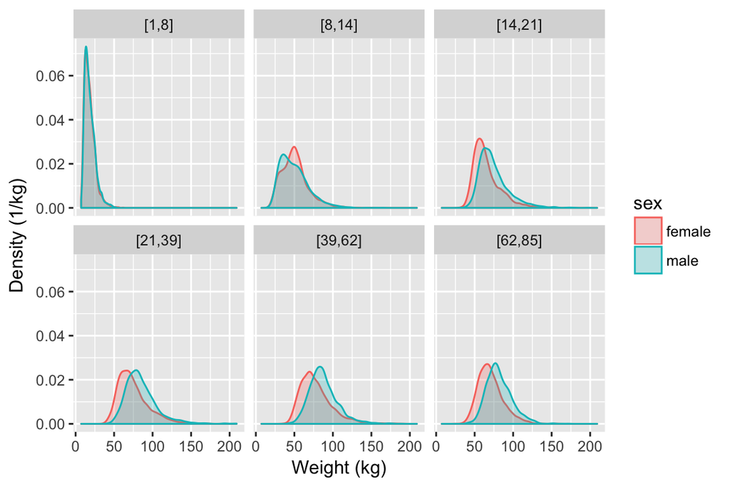

```r
NCHS %>%
  ggplot( aes(x=weight, group=sex) ) +
  geom_density(aes(color=sex, fill=sex), alpha=.25) +
  xlab("Weight (kg)") + ylab( "Density (1/kg)") +
  facet_wrap( ~ ageGroup )
```

그래프의 표현을 데이터에서 보고자 하는 것에 따라 달라진다. 예를들어, 몸무게가 나이에 따라 어떻게 변하는지 보고 싶은 경우, `sex`를 facet의 변수로, `age`를 그룹 변수로 사용하는것이 나을 것이다.

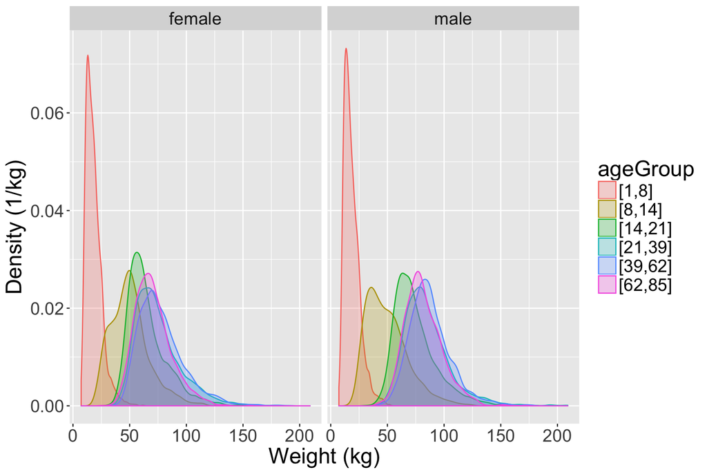

```r
NCHS %>%
  ggplot( aes(x=weight) ) +
  geom_density(aes(color=ageGroup, fill=ageGroup), alpha=.25) +
  xlab("Weight (kg)") + ylab( "Density (1/kg)") +
  facet_wrap( ~ sex ) + theme(text = element_text(size = 20))
```

### Boxplot and Violin geoms

density plot보다 boxplot이 선호되는 경우도 있다. Boxplot을 해석하는 방법은 이미 안다고 생각하고 생략한다.

`mpg` 데이터 테이블로 예시를 살펴보자.

```r
head(ggplot2::mpg,3)
```

| manufacturer | model | displ | year | cyl | trans | drv | cty | hwy | fl | class |
| --- | --- | --- | --- | --- | --- | --- | --- | --- | --- | --- |
| audi | a4 | 1.8 | 1999 | 4 | auto(l5) | f | 18 | 29 | p | compact |
| audi | a4 | 1.8 | 1999 | 4 | manual(m5) | f | 21 | 29 | p | compact |
| audi | a4 | 2.0 | 2008 | 4 | manual(m6) | f | 20 | 31 | p | compact |

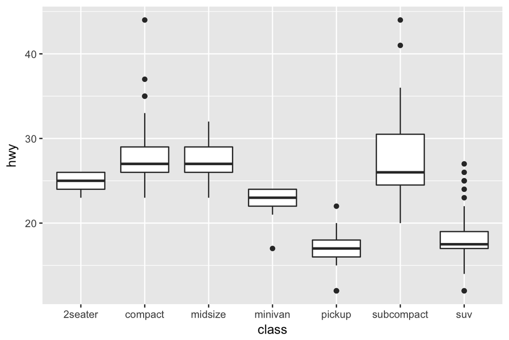

```r
p <- mpg %>% ggplot(aes(class, hwy))
p + geom_boxplot()
```

[`geom_jitter()`](http://blog.naver.com/PostView.nhn?blogId=coder1252&logNo=220986086164&categoryNo=1&parentCategoryNo=0&viewDate=&currentPage=1&postListTopCurrentPage=1&from=postView)은 point를 그래프 위에 표현하여 데이터의 분포를 대략적으로 알 수 있게 해준다.

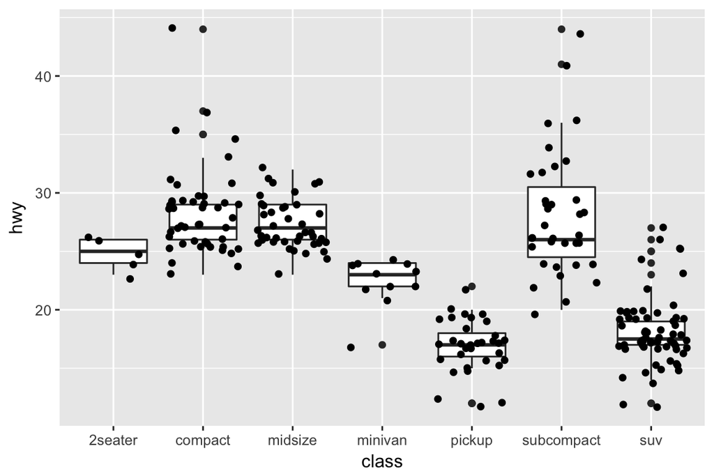

```r
p <- mpg %>% ggplot(aes(class, hwy))
p + geom_boxplot() + geom_jitter()
```

`geom_boxplot()` 내부의 aesethic `fill`을 이용하여 boxplot의 색을 변경할 수 있다.

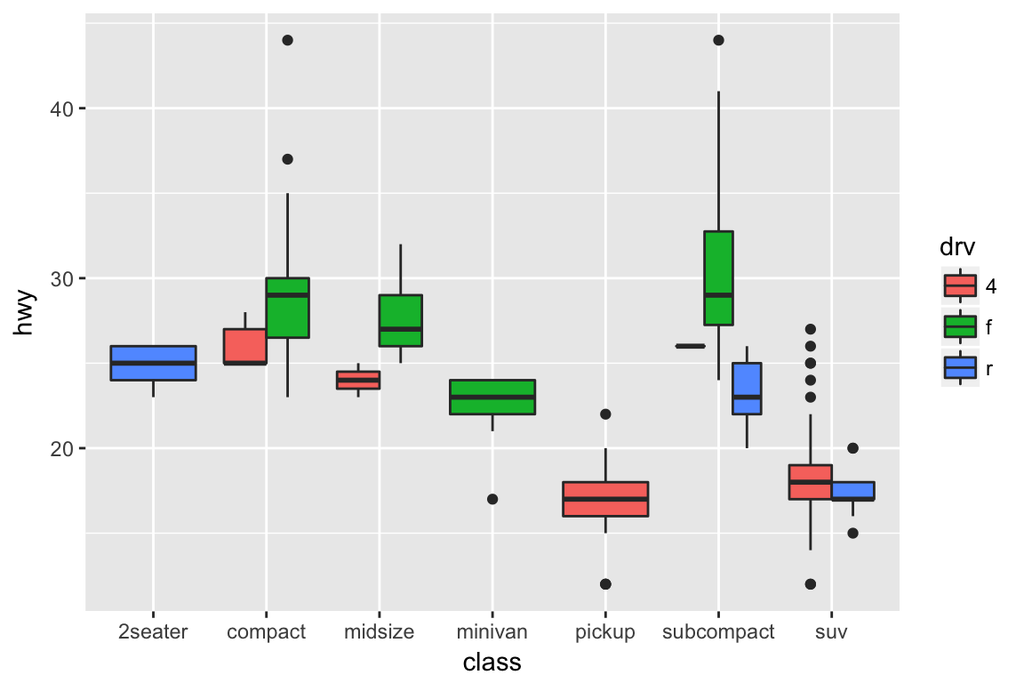

```r
p <- mpg %>% ggplot(aes(class, hwy))
p + geom_boxplot(aes(fill=drv))
```

`NCHS` 데이터로 boxplot 예시를 살펴보자:

```r
NCHS %>% select(age,weight,sex,diabetic,ageGroup) %>%
  head(3)
```

| age | weight | sex | diabetic | ageGroup |
| --- | --- | --- | --- | --- |
| 2 | 12.5 | female | Not | [1,8] |
| 77 | 75.4 | male | Not | [62,85] |
| 10 | 32.9 | female | Not | [8,14] |

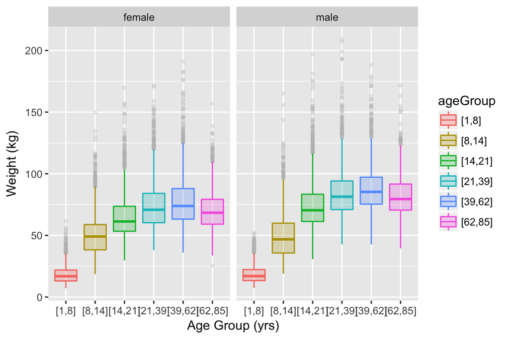

```r
NCHS %>%
  ggplot( aes(y=weight, x=ageGroup ) ) +
  geom_boxplot(
    aes(color=ageGroup, fill=ageGroup),
    alpha=.25, outlier.size=1, outlier.colour="gray") +
  ylab("Weight (kg)") + xlab( "Age Group (yrs)") +
  facet_wrap( ~ sex )
```

*violin* glyph 는 boxplot과 비슷하면서도 boxplot보다는 많은 정보를 제공한다.

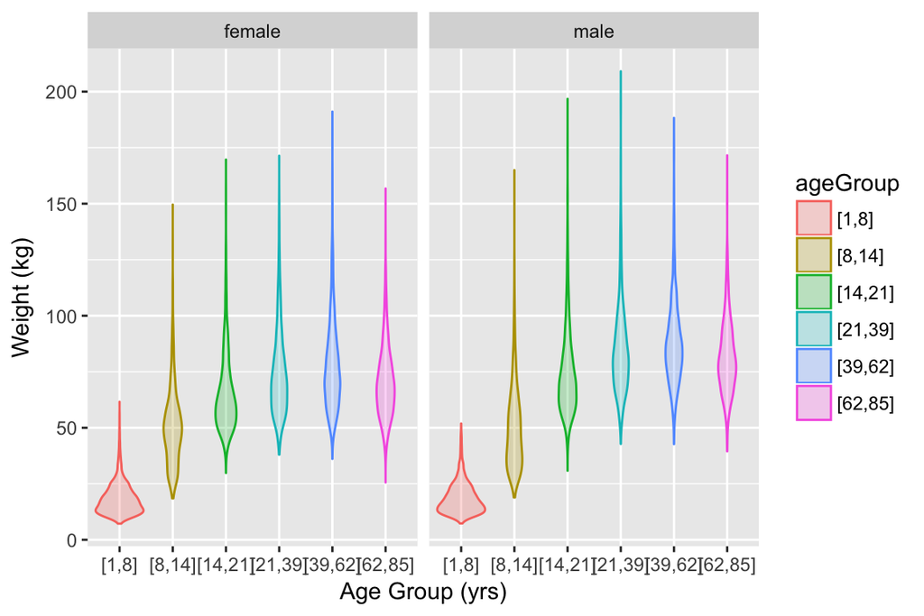

```r
NCHS %>%
  ggplot( aes(y=weight, x=ageGroup) ) +
  geom_violin( aes(color=ageGroup, fill=ageGroup),
    alpha=.25) +
  ylab("Weight (kg)") + xlab( "Age Group (yrs)") +
  facet_wrap( ~ sex )
```

box glyphs와 violin glyphs은 density glyph에 비해 더 많은 데이터를 한 그래프에 표현할 수 있도록한다. 아래는 당뇨병이 있는 사람들의 정보가 빨간색으로 표현된 box plot이다.

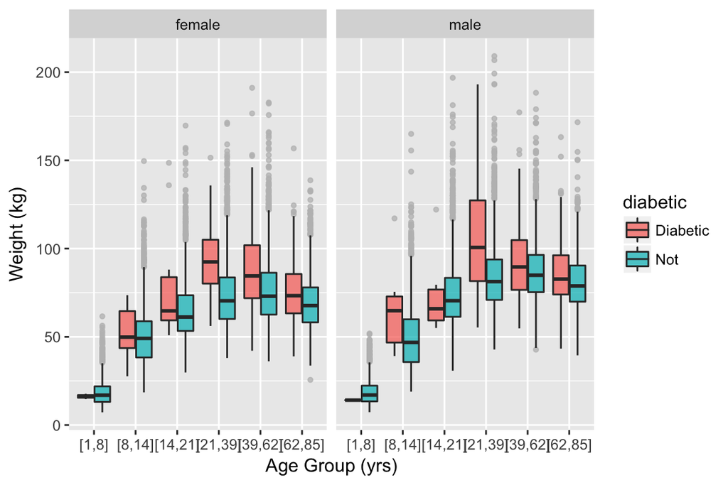

```r
NCHS %>%
  ggplot(aes(y=weight, x=ageGroup)) + geom_boxplot(aes(fill=diabetic), position = position_dodge(width = 0.8),outlier.size = 1, outlier.colour = "gray", alpha=.75) + facet_grid(.~sex) + ylab("Weight (kg)") + xlab("Age Group (yrs)")
```

### `group` aesthetic

`x`가 numeric인 경우 points는 같은 그룹에 속하며, `x`가 categorical인 경우는 각각의 point들은 각각 서로 다른 그룹에 속한다. 즉, 각각의 점이 unique한 그룹을 가진다.

예시:

```r
#we can convert a string in the form of a table into a data frame using read.table()
df = read.table(text =
"School      Year    Value
A           1998    5
B           1999    10
C           2000    7
A           2001    17
B           2002    15
C           2003    20",  header = TRUE)

df
```

| School | Year | Value |
| --- | --- | --- |
| A | 1998 | 5 |
| B | 1999 | 10 |
| C | 2000 | 7 |
| A | 2001 | 17 |
| B | 2002 | 15 |
| C | 2003 | 20 |

#### Numeric x

x가 numeric인 경우, data point는 자연스럽게 ordering을 가지게 된다. 따라서 `geom_line()`의 명령어를 받는 순간, x 축에서 자신에게 가장 가까운 점들과 서로 연결된다.

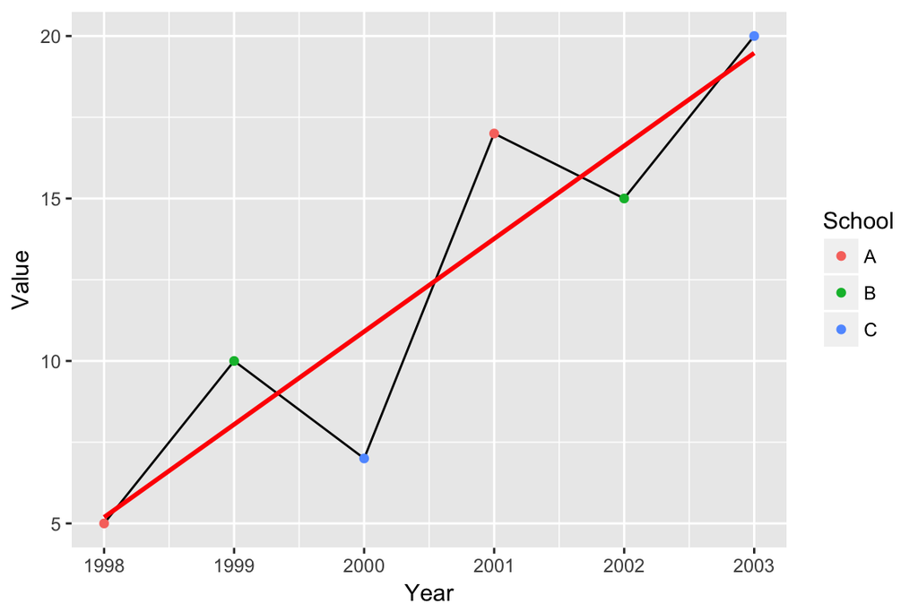

```r
df %>% ggplot(aes(x = Year, y = Value)) +
   geom_line() + geom_point(aes(colour=School)) + geom_smooth( method = "lm", se = FALSE, col="red")
```

그리고 모든 점들이 하나의 그룹에 속하기 때문에, `geom_smooth()`의 명령어를 받을 때, 하나의 직선이 생성된다.

만약 `group=School`의 aesthetic을 추가하게 되면 점들은 이제 `school`에 따라 서로 다른 그룹을 가지게 되고, 따라서 `geom_smooth()` 명령어는 여러 직선을 생성해낸다.

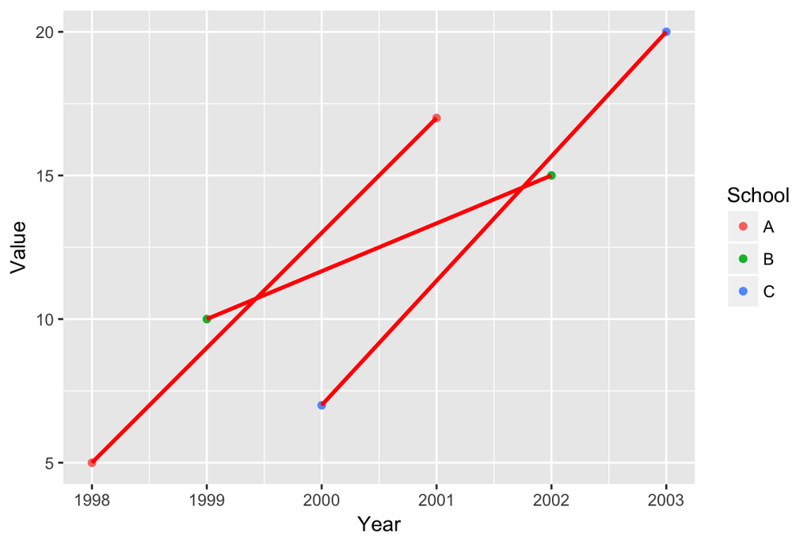

```r
df %>% ggplot(aes(x = Year, y = Value, group=School)) +
   geom_line() + geom_point(aes(colour=School)) + geom_smooth( method = "lm", se = FALSE, col="red")
```

#### categorical x

x가 categorical인 경우, 모든 점은 서로 다른 그룹을 가지기 때문에 `group` aesthetic 없이는 `geom_line()`나 `geom_smooth()`의 명령어가 아무런 line을 생성하지 않는다.

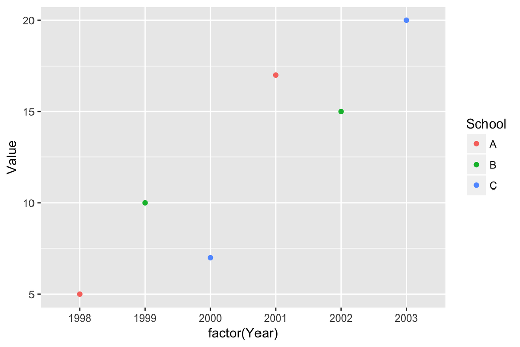

```r
df %>% ggplot(aes(x = factor(Year), y = Value)) +
  geom_line() + geom_point(aes(colour=School)) + geom_smooth( method = "lm", se = FALSE, col="red")
```

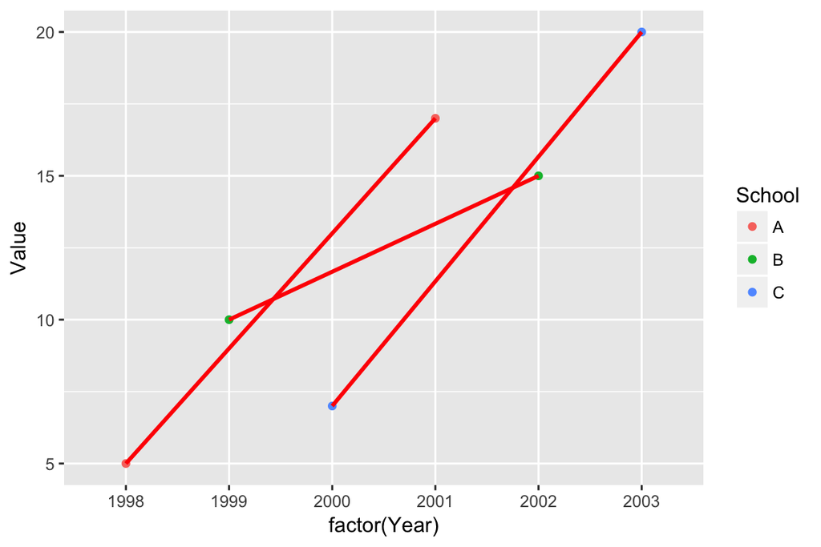

```r
df %>% ggplot(aes(x = factor(Year), y = Value, group = School)) +  geom_line() + geom_point(aes(colour=School)) + geom_smooth( method = "lm", se = FALSE, col="red")
```

## 3. Regular Expression (i.e. regex)

**regular expression** (regex)은 문자열에서의 패턴을 의미한다.

예시: regex “[a-cx-z]” 는 “a”,“b”,“c”,“x”,“y”,“z”와 매치된다.

예시: regex “ba+d”는 “bad”, “baad”, “baaad” 등과 매치되지만, “bd”와는 매치되지 않는다.

regex의 사용:

#### `filter()`와 `grepl()`을 사용하여 문자열에 원하는 패턴이 존재하는지 확인한다.

예를들어, BabyNames 데이터를 다음과 같이 정리한 후,

```r
NameList <- BabyNames %>%
  mutate( name=tolower(name) ) %>%
  group_by( name, sex ) %>%
  summarise( total=sum(count) ) %>%
  arrange( desc(total))

head(NameList,3)
```

```
## # A tibble: 3 x 3
## # Groups:   name [3]
##     name   sex   total
##    <chr> <chr>   <int>
## 1  james     M 5091189
## 2   john     M 5073958
## 3 robert     M 4789776
```

`grepl()` 함수는 regular expression과 문자열을 비교하여, 만약 서로가 매치되는 경우, TRUE를 매치되지 않는 경우, FALSE를 반환한다. 그리고 regular expression은 “”안에 들어간다.

- name 중 “shine”을 가지고 있는 경우 (“sunshine” 혹은 “moonshine”):

  ```r
  NameList %>%
    filter( grepl( "shine", name ) ) %>%
    head(3)
  ```

  ```
  ## # A tibble: 3 x 3
  ## # Groups:   name [3]
  ##       name   sex total
  ##      <chr> <chr> <int>
  ## 1 sunshine     F  4959
  ## 2  shineka     F   150
  ## 3    shine     F    95
  ```

- name 중 적어도 3개의 모음을 연속적으로 가진 경우:

```r
NameList %>%
  filter( grepl( "[aeiou]{3,}", name ) ) %>%
  head(3)
```

```
## # A tibble: 3 x 3
## # Groups:   name [3]
##     name   sex  total
##    <chr> <chr>  <int>
## 1  louis     M 389910
## 2 louise     F 331551
## 3 isaiah     M 177412
```

- name 중 적어도 3개의 자음을 연속적으로 가진 경우:

```r
NameList %>%
  filter( grepl( "[^aeiou]{3,}", name ) ) %>%
  head(3)
```

```
## # A tibble: 3 x 3
## # Groups:   name [3]
##          name   sex   total
##         <chr> <chr>   <int>
## 1 christopher     M 1984307
## 2     matthew     M 1540182
## 3     anthony     M 1391462
```

- name 중 “mn”를 포함하는 경우:

```r
NameList %>%
  filter( grepl( "mn", name ) ) %>%
  head()
```

```
## # A tibble: 6 x 3
## # Groups:   name [5]
##      name   sex  total
##     <chr> <chr>  <int>
## 1  autumn     F 104408
## 2  sumner     M   2287
## 3    amna     F   1099
## 4 domnick     M    405
## 5  tatumn     F    280
## 6  autumn     M    258
```

- name 중 첫번째, 세번째, 그리고 다섯번째 글자가 자음인 경우:

```r
NameList %>%
  filter( grepl( "^[^aeiou].[^aeiou].[^aeiou]", name ) ) %>%
  head()
```

```
## # A tibble: 6 x 3
## # Groups:   name [6]
##          name   sex   total
##         <chr> <chr>   <int>
## 1       james     M 5091189
## 2      robert     M 4789776
## 3       david     M 3565229
## 4      joseph     M 2557792
## 5 christopher     M 1984307
## 6     matthew     M 1540182
```

남자아이와 여자아이의 이름 중 모음으로 끝나는 경우의 수:

```r
NameList %>%
  filter( grepl( "[aeiou]$", name ) ) %>%
  group_by( sex ) %>%
  summarise( total=sum(total) )
```

| sex | total |
| --- | --- |
| F | 96702371 |
| M | 21054791 |

여자아이의 이름의 경우가 남자아이 이름의 경우보다 모음으로 끝나는 경우가 약 5배 정도 많다.

## Regular Expressions 작성 방법

- 온라인으로 regex을 익힐 수 있는 사이트 [online](http://regexone.com/) * regex [cheat sheet](http://krijnhoetmer.nl/stuff/regex/cheat-sheet/)

regex 기본:

- simple patterns:
  - A single `.` means “any character.”
  - A character, e.g., `b`, means just that character.
  - Characters enclosed in square brackets, e.g., `[aeiou]` means any of those characters. (So, `[aeiou]` is a pattern describing a vowel.)
  - The `^` inside square brackets means “any except these.” So, a consonant is `[^aeiou]`
- Alternatives. A vertical bar means “either.” For example `(A|a)dam` matches `Adam` and `adam`
- Repeats
  - Two simple patterns in a row, means those patterns consecutively. Example: `M[aeiou]` means a capital M followed by a lower-case vowel.
  - A simple pattern followed by a `+` means “one or more times.” For example `M(ab)+` means `M` followed by one or more `ab`.
  - A simple pattern followed by a `?` means “zero or one time.”
  - A simple pattern followed by a `*` means “zero or more times.”
  - A simple pattern followed by `{2}` means “exactly two times.” Similarly, `{2,5}` means between two and five times, `{6,}` means six times or more.
- Start and end of strings. For instance, `[aeiou]{2}` means “exactly two vowels in a row.”
  - `^` at the beginning of a regular expression means “the start of the string”
  - `$` at the end means “the end of the string.”

### 문자열의 일부를 `mutate()`과 `gsub()`를 사용하여 바꾸기

예를들어:

숫자는 많은 경우 일반적으로 천단위를 ,로 표시한다. 예를들어, 다음은 위키피디아의 [public debt](http://en.wikipedia.org/wiki/Government_debt) 데이터이다.

```r
head(Debt,3)
```

| country | debt | percentGDP |
| --- | --- | --- |
| World | $56,308 billion | 64% |
| United States | $17,607 billion | 73.60% |
| Japan | $9,872 billion | 214.30% |

천단위가 ,로 분리된 데이터들을 연산에 사용하기 위해서는 ,를 분리해내야 할 필요가 있다.

```r
Debt %>%
  mutate( debt=gsub("[$,]|billion","",debt),
          percentGDP=gsub("%", "", percentGDP))
```

| country | debt | percentGDP |
| --- | --- | --- |
| World | 56308 | 64 |
| United States | 17607 | 73.60 |
| Japan | 9872 | 214.30 |

#### 예시:

이렇게,

```r
grepl("ab*",c("a","ab", "abb","abbb", "ca","abbd"))
```

```
## [1] TRUE TRUE TRUE TRUE TRUE TRUE
```

혹은 이렇게,

```r
grepl("^ab*$",c("a","ab", "abb","abbb", "ca","abbd"))
```

```
## [1]  TRUE  TRUE  TRUE  TRUE FALSE FALSE
```

혹은 이렇게 표현할 수 있다.

```r
grepl("(^a$|^ab$|^abb$|^abbb$)",c("a","ab", "abb","abbb", "ca","abbd"))
```

```
## [1]  TRUE  TRUE  TRUE  TRUE FALSE FALSE
```

#### 또 다른 예시

데이터 테이블 `CarRegistrations`은 다음과 같다:

```r
CarRegistrations <- data.frame(c("Joe Smith","Tim Allen"),c("Ford","Toyota"),c("Taurus","Prius"),c(2007,2011),c("metalic gray","blue"),c("337 HBQ","843 OSS"),c(98739,93134))
names(CarRegistrations) <- c("owner","brand","model","model_year","color","plate","zip")
CarRegistrations
```

| owner | brand | model | model_year | color | plate | zip |
| --- | --- | --- | --- | --- | --- | --- |
| Joe Smith | Ford | Taurus | 2007 | metalic gray | 337 HBQ | 98739 |
| Tim Allen | Toyota | Prius | 2011 | blue | 843 OSS | 93134 |

당신의 직업은 경찰으로서, 뺑소니 사고가 접수된 상황을 가정하자. 증언에 의하면 차는 파란색이였으며, 번호판은 3 혹은 8로 시작하고, 그 다음은 O 혹은 Q이며, 그 다음 글자는 S 혹은 8이였다고 한다. 또한 사고가 일어난 지역은 Santa Barbara, CA (zipcode: 931)로 추정된다.

`filter()`를 이용하여 가진 정보를 regex으로 표현하면 다음과 같다.

```r
CarRegistrations %>%
  filter( grepl("blue", color), # blue car
          grepl("^[38].*[OQ].*[S8].*", plate), # license plate
          grepl("^931..$", as.character(zip)) # zip code
          )
```

| owner | brand | model | model_year | color | plate | zip |
| --- | --- | --- | --- | --- | --- | --- |
| Tim Allen | Toyota | Prius | 2011 | blue | 843 OSS | 93134 |

regex의 메타문자:

메타문자(metacharacter)은 특별한 뜻이 담기어 문자열 양식을 나타내는데 쓰인다.

`.` `\` `|` `(` `)` `[` `]` `{` `$` `*` `+` `?`

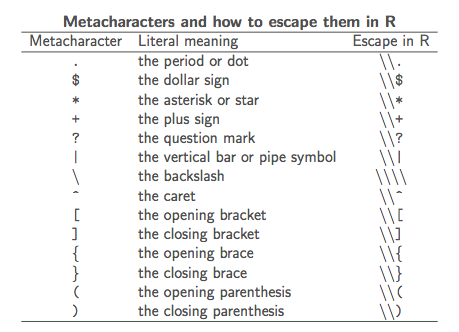

*character class*이라 불리는 `[]`는 ’그 속의 문자열 중 하나’의 의미를 가진다. 예를들어, `[ab]`은 `a` 혹은 `b`를 의미한다.

예시:

```r
grepl("[a$]", c("hello$bye", "hellobye$","adam"))  #$ has literal meaning inside []
```

```
## [1] TRUE TRUE TRUE
```

```r
grepl("[a$]$", c("hello$bye","hellobye$", "adam")) #$ is metacharacter outside of []
```

```
## [1] FALSE  TRUE FALSE
```

```r
grepl("[a\\^]", c("5^"))
```

```
## [1] TRUE
```

흔히 쓰여지는 패턴들에 대해서는 이미 built-in 패턴이 존재한다.

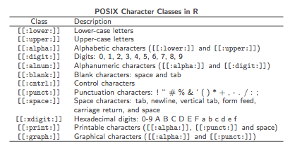

POSIX expressions 또한 character class의 특별한 한 종류이다. POSIX expressions은 해당 표현에 맞게 하나의 문자와 매치된다.

예시:

```r
x <- c ("a0b", "a1b","a12b","a&b")
grepl("a[[:digit:]]b",x)
```

```
## [1]  TRUE  TRUE FALSE FALSE
```

```r
x <- c ("a0b", "a1b","a12b","a&b")
grepl("a[[:digit:]]+b",x)
```

```
## [1]  TRUE  TRUE  TRUE FALSE
```

```r
x <- c ("a0b", "a1b","a12b","a&b")
grepl("a[^[:digit:]]+b",x)
```

```
## [1] FALSE FALSE FALSE  TRUE
```

```r
x <- c (3,"5","a","b","?")
grepl("[[:digit:]abc]",x)
```

```
## [1]  TRUE  TRUE  TRUE  TRUE FALSE
```

## Discuss

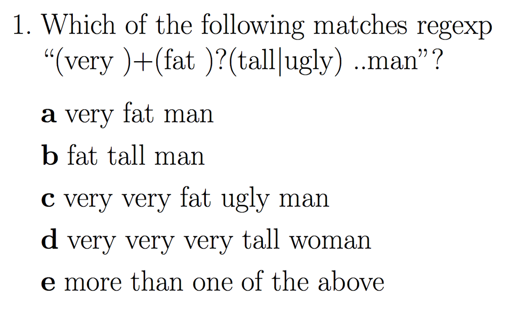

## 정리

Regular expressions을 사용하는데에는 다양한 목적이 있다:

- 목적1: 문자열에 패턴이 포함되는지를 확인하고 싶을 때는 `filter()` 와 `grepl()` 함수를 사용한다.
1. grepl() 은 문자형 벡터에서 regex과 매치되는 부분을 찾고, 결과는 TRUE/FALSE의 Boolean 벡터로 반환한다.
2. syntax: `grepl(regex,vec)`

예시: 성경의 이름들로 구성된 데이터셋:

```r
BibleNames <- read.csv("http://tiny.cc/dcf/BibleNames.csv")
head(BibleNames)
```

| name | meaning |
| --- | --- |
| Aaron | a teacher; lofty; mountain of strength |
| Abaddon | the destroyer |
| Abagtha | father of the wine-press |
| Abana | made of stone; a building |
| Abarim | passages; passengers |
| Abba | father |

“bar”, “dam”, “lory”(중 하나라도)이 포함된 이름은?

```r
BibleNames %>%
  filter(grepl("(bar)|(dam)|(lory)", name)) %>%
  head()
```

| name | meaning |
| --- | --- |
| Abarim | passages; passengers |
| Aceldama | field of blood |
| Adam | earthy; red |
| Adamah | red earth; of blood |
| Adami | my man; red; earthy; human |
| Bethabara | the house of confidence |

- 목적2: 패턴의 일부를 다른 것으로 바꾸려면 `mutate()` 와 `gsub()`를 사용한다. details:
1. `gsub()` 는 문자현 벡터에서 regex과 매치되는 부분을 찾아 매치된 모든 부분을 다른 어떤 것으로 바꾼다.
2. syntax:`gsub(regex, replacement, vec)`

아래의 데이터 테이블에서 숫자가 위치한 셀에 오직 숫자만이 표현되도록 바꿔보자.

```r
head(Debt)
```

| country | debt | percentGDP |
| --- | --- | --- |
| World | $56,308 billion | 64% |
| United States | $17,607 billion | 73.60% |
| Japan | $9,872 billion | 214.30% |

```r
Debt %>%
  mutate( debt=gsub("[$,]|billion","",debt),
          percentGDP=gsub("%", "", percentGDP))
```

| country | debt | percentGDP |
| --- | --- | --- |
| World | 56308 | 64 |
| United States | 17607 | 73.60 |
| Japan | 9872 | 214.30 |

## Discuss

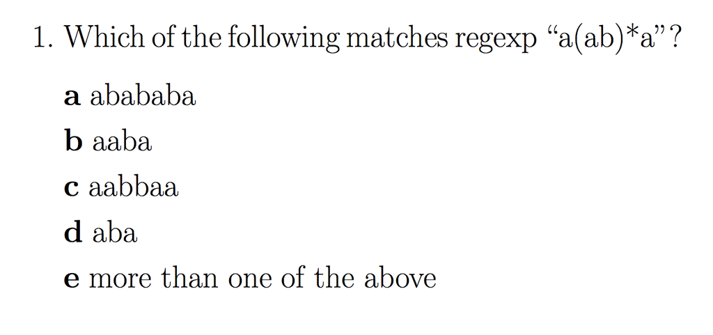